# Tugas MPDW 4

Fedora

2023-09-21

## White Noise

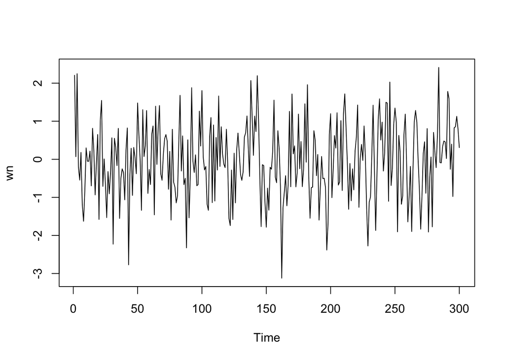

```r
wn <- rnorm(300)
ts.plot(wn)
```

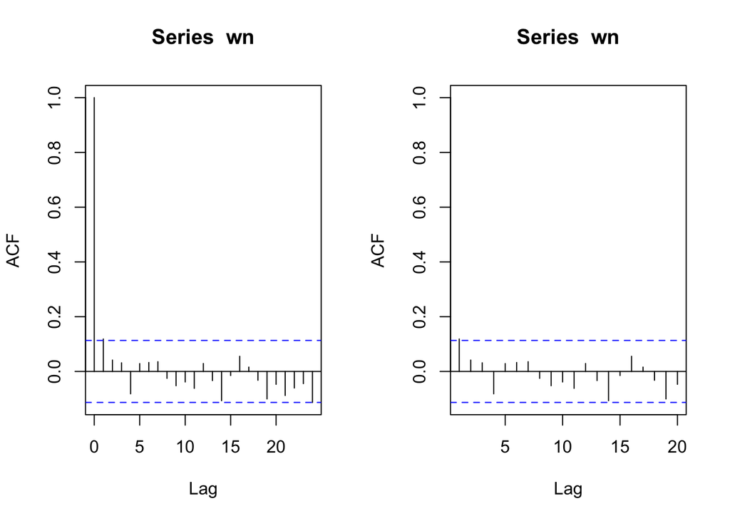

```r
par(mfrow = c(1, 2))
acf(wn)
acf(wn, xlim = c(1, 20))
```

## Pembangkitan Proses MA(2)

Akan dicoba membangkitkan proses MA paling sederhana, yaitu MA(2) dengan $\theta_1 = 0.4$ dan $\theta_2 = 0.6$ sebanyak 300 observasi dan $c=0$. Karena diperlukan satu nilai awal untuk $e_{t-1}$, masukkan nilai pertama white noise sebagai nilai awal tersebut.

```r
set.seed(025)
ma <- wn[c(1,2)]
```

Nilai-nilai selanjutnya dapat dicari melalui *loop*. Bentuk loop dapat dilihat dari rumus MA(1) yang hendak dibangkitkan:

$$y_t = e_t+0.4e_{t-1}+0.6e_{t-2}$$

```r
for(i in 3:300){
   ma[i] <- wn[i] + 0.4 * wn[i - 1] + 0.6 * wn[i - 2]
}
ma
```

```
##   [1]  2.206520198  0.069013838  3.599082805  0.746755279  0.725383395
##   [6] -0.153854162 -1.439932484 -1.992549042 -2.181617451 -1.005079679
##  [11] -0.422010487  0.106442241  0.165051667 -0.642674761  0.664252079
##  [16]  0.126844614 -0.358208788 -0.320238727  0.058238193 -1.365722600
##  [21]  0.778206913  1.006047332  0.519333644  0.652283389 -1.081585803
##  [26] -1.789415009 -1.329834797 -1.952927219 -0.878310482 -0.108887618
##  [31] -2.196129830 -0.001596443 -0.809828058  0.286873714  0.928855501
##  [36] -1.327378309 -0.638970823 -1.384397707 -0.746638730 -1.351410249
##  [41] -0.384127765  0.283558895 -2.293652457 -1.012888150 -1.533555033
##  [46] -1.071855523  0.104428461 -0.399802066 -0.174415499  1.354128288
##  [51]  1.008267233  1.111410160 -0.967130095  0.746440534 -0.210957962
##  [56]  1.164910042  1.464823572 -0.170853346  0.143744664 -1.305829273
##  [61]  0.236895178  0.742682497 -0.711532017  1.336047378 -0.450962831
##  [66]  1.616295108  1.664605670  0.685032304  0.144587241 -0.322967123
##  [71]  0.259324232  0.939844776  1.059668133 -0.206261790  0.177835299
```

[output cut: 45 more lines]

Selain menggunakan cara di atas, pembangkitan proses MA(2) dapat dilakukan dengan fungsi `arima.sim()` sebagai berikut.

```r
ma1 <- arima.sim(list(order=c(0,0,2), ma=c(0.4,0.6)), n=300)
ma1
```

```
## Time Series:
## Start = 1
## End = 300
## Frequency = 1
##   [1] -1.6970441728 -0.7647462055 -2.0635018113 -0.8526663128  0.6557542026
##   [6]  0.9375938322  1.3445905424  0.2887442737 -1.7061570512 -2.0568027010
##  [11] -2.1235876522 -2.4705296184 -0.8286272188  0.0868231098 -0.2961256638
##  [16]  1.2322393095  1.5007828511  0.1860300243  1.0810361574 -0.2141123128
##  [21]  0.5572179760  2.5311371904 -0.5453832031 -0.3171324316 -0.4900129941
##  [26] -0.2326869310 -0.5804683751 -1.3200711497 -2.2486442864 -1.5303102214
##  [31] -0.6168913002 -0.2514767843  0.5287994210  1.2526459755 -0.7584942094
##  [36] -0.6345578957 -2.2461906806 -1.7927592323 -0.7608064921 -0.3907538878
##  [41]  1.0438982819 -0.1153377014  1.1122931976 -0.0301775326  0.7385207198
##  [46] -2.2601031899 -0.4151604757 -2.0028011953  0.0694657592  0.0857561860
##  [51] -1.0702481173 -0.6307982469  1.0904896454 -0.4338742298  0.0078618202
```

[output cut: 49 more lines]

## Karakteristik MA(2)

### Plot Time Series

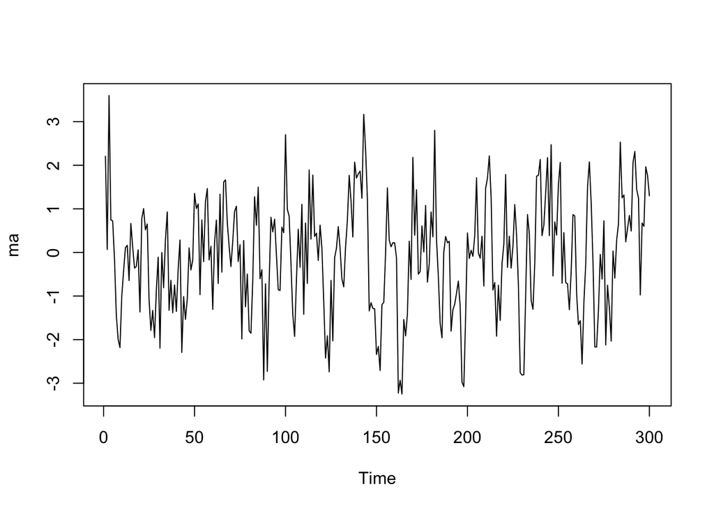

```r
ts.plot(ma)
```

Berdasarkan plot time series, terlihat bahwa data MA(1) yang dibangkitkan stasioner dalam rataan

### Plot ACF

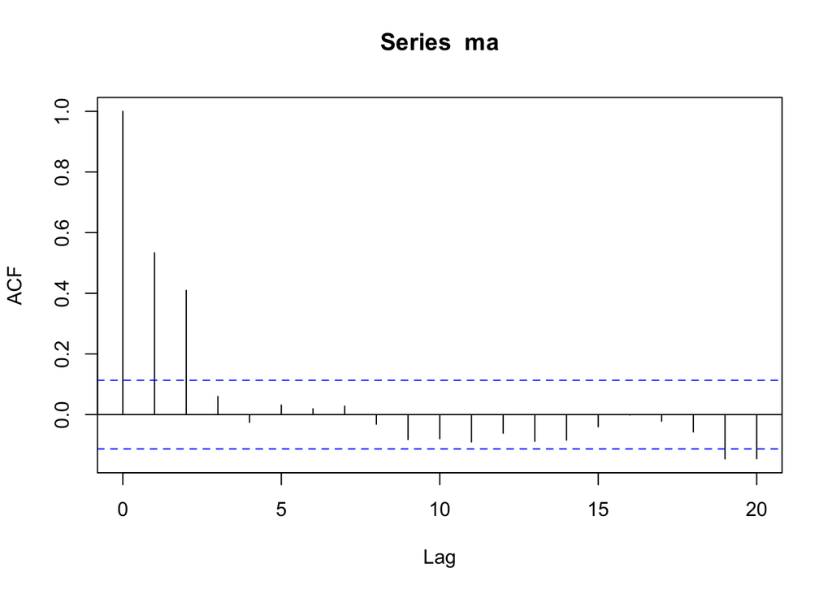

```r
acf(ma,lag.max = 20)
```

Berdasarkan plot AFC tersebut, terlihat bahwa plot ACF *cuts off* di lag pertama dan kedua

### Plot PACF

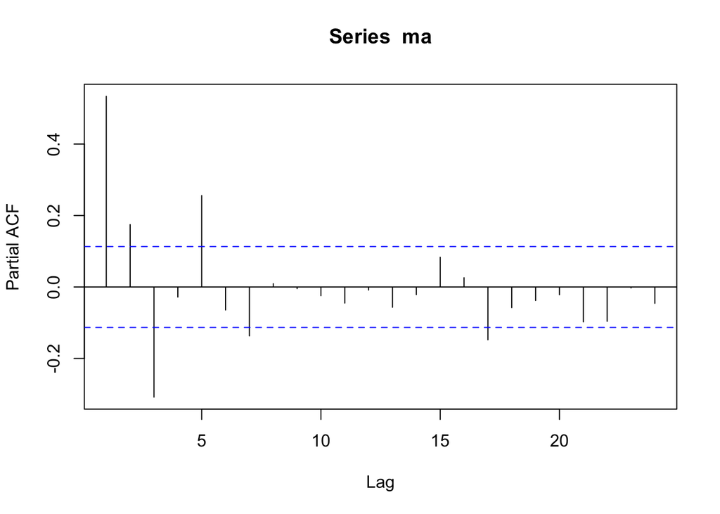

```r
pacf(ma)
```

Berdasarkan plot PACF tersebut, terlihat bahwa plot PACF cenderung *tails off* dan membentuk gelombang sinus

### Plot EACF

```r
TSA::eacf(ma)
```

```
## AR/MA
##   0 1 2 3 4 5 6 7 8 9 10 11 12 13
## 0 x x o o o o o o o o o  o  o  o
## 1 x x x o o o o o o o o  o  o  o
## 2 x x x x o o o o o o o  o  o  o
## 3 o x o x o o o o o o o  o  o  o
## 4 o x o x x x o o o o o  o  o  o
## 5 x x x x x o o o o o o  o  o  o
## 6 x x x x x x x x o o o  o  o  o
## 7 o o x x o o o x x o o  o  o  o
```

### Scatterplot Antar Lag

#### Korelasi antara $Y_t$ dengan $Y_{t-1}$

```r
#Yt
yt_ma <- ma[-1]
yt_ma
```

```
##   [1]  0.069013838  3.599082805  0.746755279  0.725383395 -0.153854162
##   [6] -1.439932484 -1.992549042 -2.181617451 -1.005079679 -0.422010487
##  [11]  0.106442241  0.165051667 -0.642674761  0.664252079  0.126844614
##  [16] -0.358208788 -0.320238727  0.058238193 -1.365722600  0.778206913
##  [21]  1.006047332  0.519333644  0.652283389 -1.081585803 -1.789415009
##  [26] -1.329834797 -1.952927219 -0.878310482 -0.108887618 -2.196129830
##  [31] -0.001596443 -0.809828058  0.286873714  0.928855501 -1.327378309
##  [36] -0.638970823 -1.384397707 -0.746638730 -1.351410249 -0.384127765
##  [41]  0.283558895 -2.293652457 -1.012888150 -1.533555033 -1.071855523
##  [46]  0.104428461 -0.399802066 -0.174415499  1.354128288  1.008267233
##  [51]  1.111410160 -0.967130095  0.746440534 -0.210957962  1.164910042
##  [56]  1.464823572 -0.170853346  0.143744664 -1.305829273  0.236895178
##  [61]  0.742682497 -0.711532017  1.336047378 -0.450962831  1.616295108
##  [66]  1.664605670  0.685032304  0.144587241 -0.322967123  0.259324232
##  [71]  0.939844776  1.059668133 -0.206261790  0.177835299 -1.984331100
```

[output cut: 45 more lines]

```r
#Yt-1
yt_1_ma <- ma[-300]
yt_1_ma
```

```
##   [1]  2.206520198  0.069013838  3.599082805  0.746755279  0.725383395
##   [6] -0.153854162 -1.439932484 -1.992549042 -2.181617451 -1.005079679
##  [11] -0.422010487  0.106442241  0.165051667 -0.642674761  0.664252079
##  [16]  0.126844614 -0.358208788 -0.320238727  0.058238193 -1.365722600
##  [21]  0.778206913  1.006047332  0.519333644  0.652283389 -1.081585803
##  [26] -1.789415009 -1.329834797 -1.952927219 -0.878310482 -0.108887618
##  [31] -2.196129830 -0.001596443 -0.809828058  0.286873714  0.928855501
##  [36] -1.327378309 -0.638970823 -1.384397707 -0.746638730 -1.351410249
##  [41] -0.384127765  0.283558895 -2.293652457 -1.012888150 -1.533555033
##  [46] -1.071855523  0.104428461 -0.399802066 -0.174415499  1.354128288
##  [51]  1.008267233  1.111410160 -0.967130095  0.746440534 -0.210957962
##  [56]  1.164910042  1.464823572 -0.170853346  0.143744664 -1.305829273
##  [61]  0.236895178  0.742682497 -0.711532017  1.336047378 -0.450962831
##  [66]  1.616295108  1.664605670  0.685032304  0.144587241 -0.322967123
##  [71]  0.259324232  0.939844776  1.059668133 -0.206261790  0.177835299
```

[output cut: 45 more lines]

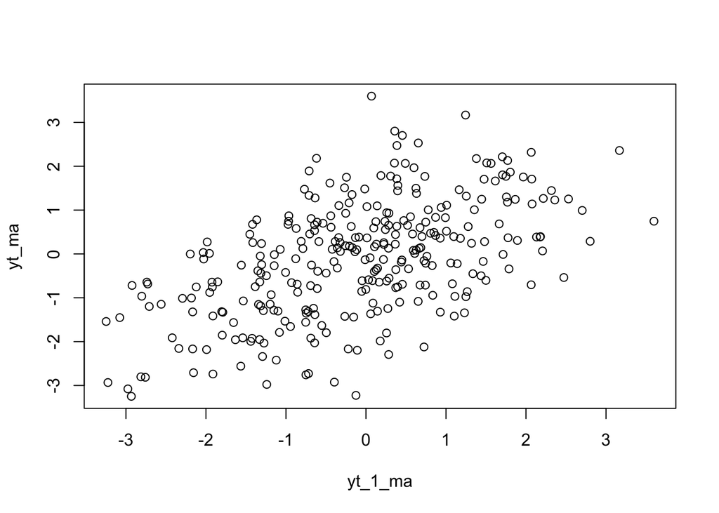

```r
plot(y=yt_ma,x=yt_1_ma)
```

Berdasarkan scatterplot tersebut, terlihat bahwa terdapat hubungan positif antara $Y_t$ dengan $Y_{t-1}$. Hal ini sesuai dengan teori yang ada

```r
cor(yt_ma,yt_1_ma)
```

```
## [1] 0.5373943
```

#### Korelasi antara $Y_t$ dengan $Y_{t-2}$

```r
#Yt
yt_ma2 <- ma[-c(1,2)]
yt_ma2
```

```
##   [1]  3.599082805  0.746755279  0.725383395 -0.153854162 -1.439932484
##   [6] -1.992549042 -2.181617451 -1.005079679 -0.422010487  0.106442241
##  [11]  0.165051667 -0.642674761  0.664252079  0.126844614 -0.358208788
##  [16] -0.320238727  0.058238193 -1.365722600  0.778206913  1.006047332
##  [21]  0.519333644  0.652283389 -1.081585803 -1.789415009 -1.329834797
##  [26] -1.952927219 -0.878310482 -0.108887618 -2.196129830 -0.001596443
##  [31] -0.809828058  0.286873714  0.928855501 -1.327378309 -0.638970823
##  [36] -1.384397707 -0.746638730 -1.351410249 -0.384127765  0.283558895
##  [41] -2.293652457 -1.012888150 -1.533555033 -1.071855523  0.104428461
##  [46] -0.399802066 -0.174415499  1.354128288  1.008267233  1.111410160
##  [51] -0.967130095  0.746440534 -0.210957962  1.164910042  1.464823572
##  [56] -0.170853346  0.143744664 -1.305829273  0.236895178  0.742682497
##  [61] -0.711532017  1.336047378 -0.450962831  1.616295108  1.664605670
##  [66]  0.685032304  0.144587241 -0.322967123  0.259324232  0.939844776
##  [71]  1.059668133 -0.206261790  0.177835299 -1.984331100  0.273373036
```

[output cut: 45 more lines]

```r
#Yt-2
yt_2_ma <- ma[-c(299,300)]
yt_2_ma
```

```
##   [1]  2.206520198  0.069013838  3.599082805  0.746755279  0.725383395
##   [6] -0.153854162 -1.439932484 -1.992549042 -2.181617451 -1.005079679
##  [11] -0.422010487  0.106442241  0.165051667 -0.642674761  0.664252079
##  [16]  0.126844614 -0.358208788 -0.320238727  0.058238193 -1.365722600
##  [21]  0.778206913  1.006047332  0.519333644  0.652283389 -1.081585803
##  [26] -1.789415009 -1.329834797 -1.952927219 -0.878310482 -0.108887618
##  [31] -2.196129830 -0.001596443 -0.809828058  0.286873714  0.928855501
##  [36] -1.327378309 -0.638970823 -1.384397707 -0.746638730 -1.351410249
##  [41] -0.384127765  0.283558895 -2.293652457 -1.012888150 -1.533555033
##  [46] -1.071855523  0.104428461 -0.399802066 -0.174415499  1.354128288
##  [51]  1.008267233  1.111410160 -0.967130095  0.746440534 -0.210957962
##  [56]  1.164910042  1.464823572 -0.170853346  0.143744664 -1.305829273
##  [61]  0.236895178  0.742682497 -0.711532017  1.336047378 -0.450962831
##  [66]  1.616295108  1.664605670  0.685032304  0.144587241 -0.322967123
##  [71]  0.259324232  0.939844776  1.059668133 -0.206261790  0.177835299
```

[output cut: 45 more lines]

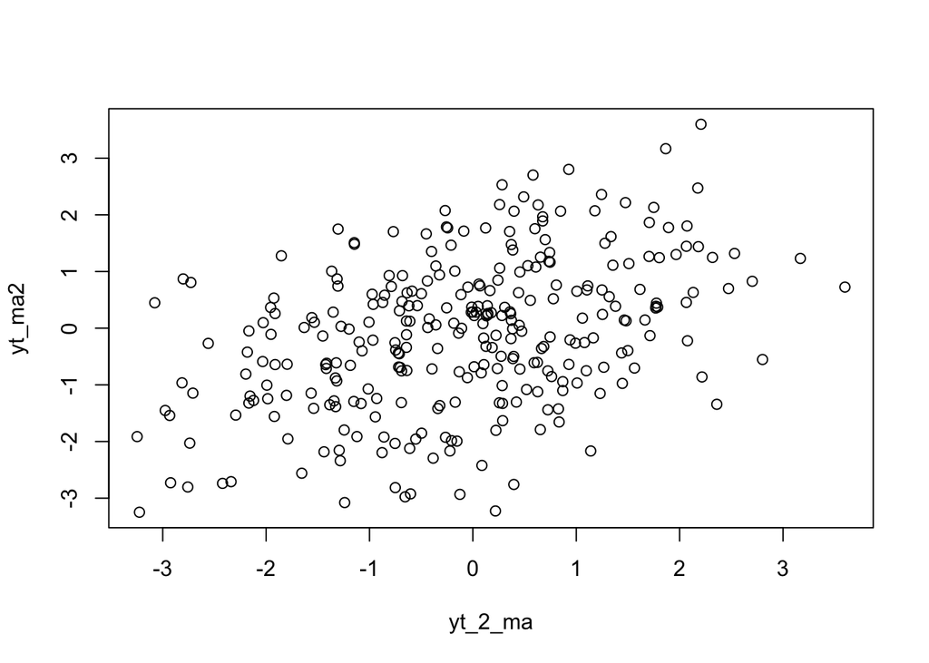

```r
plot(y=yt_ma2,x=yt_2_ma)
```

Berdasarkan scatterplot tersebut, terlihat bahwa cenderung terdapat hubungan antara $Y_t$ dengan $Y_{t-2}$.

```r
cor(yt_ma2,yt_2_ma)
```

```
## [1] 0.4138839
```

#### Korelasi antara $Y_t$ dengan $Y_{t-3}$

```r
#Yt
yt_ma3 <- ma[-c(1,2,3)]
yt_ma3
```

```
##   [1]  0.746755279  0.725383395 -0.153854162 -1.439932484 -1.992549042
##   [6] -2.181617451 -1.005079679 -0.422010487  0.106442241  0.165051667
##  [11] -0.642674761  0.664252079  0.126844614 -0.358208788 -0.320238727
##  [16]  0.058238193 -1.365722600  0.778206913  1.006047332  0.519333644
##  [21]  0.652283389 -1.081585803 -1.789415009 -1.329834797 -1.952927219
##  [26] -0.878310482 -0.108887618 -2.196129830 -0.001596443 -0.809828058
##  [31]  0.286873714  0.928855501 -1.327378309 -0.638970823 -1.384397707
##  [36] -0.746638730 -1.351410249 -0.384127765  0.283558895 -2.293652457
##  [41] -1.012888150 -1.533555033 -1.071855523  0.104428461 -0.399802066
##  [46] -0.174415499  1.354128288  1.008267233  1.111410160 -0.967130095
##  [51]  0.746440534 -0.210957962  1.164910042  1.464823572 -0.170853346
##  [56]  0.143744664 -1.305829273  0.236895178  0.742682497 -0.711532017
##  [61]  1.336047378 -0.450962831  1.616295108  1.664605670  0.685032304
##  [66]  0.144587241 -0.322967123  0.259324232  0.939844776  1.059668133
##  [71] -0.206261790  0.177835299 -1.984331100  0.273373036 -1.244758653
```

[output cut: 45 more lines]

```r
#Yt-2
yt_3_ma <- ma[-c(298,299,300)]
yt_3_ma
```

```
##   [1]  2.206520198  0.069013838  3.599082805  0.746755279  0.725383395
##   [6] -0.153854162 -1.439932484 -1.992549042 -2.181617451 -1.005079679
##  [11] -0.422010487  0.106442241  0.165051667 -0.642674761  0.664252079
##  [16]  0.126844614 -0.358208788 -0.320238727  0.058238193 -1.365722600
##  [21]  0.778206913  1.006047332  0.519333644  0.652283389 -1.081585803
##  [26] -1.789415009 -1.329834797 -1.952927219 -0.878310482 -0.108887618
##  [31] -2.196129830 -0.001596443 -0.809828058  0.286873714  0.928855501
##  [36] -1.327378309 -0.638970823 -1.384397707 -0.746638730 -1.351410249
##  [41] -0.384127765  0.283558895 -2.293652457 -1.012888150 -1.533555033
##  [46] -1.071855523  0.104428461 -0.399802066 -0.174415499  1.354128288
##  [51]  1.008267233  1.111410160 -0.967130095  0.746440534 -0.210957962
##  [56]  1.164910042  1.464823572 -0.170853346  0.143744664 -1.305829273
##  [61]  0.236895178  0.742682497 -0.711532017  1.336047378 -0.450962831
##  [66]  1.616295108  1.664605670  0.685032304  0.144587241 -0.322967123
##  [71]  0.259324232  0.939844776  1.059668133 -0.206261790  0.177835299
```

[output cut: 45 more lines]

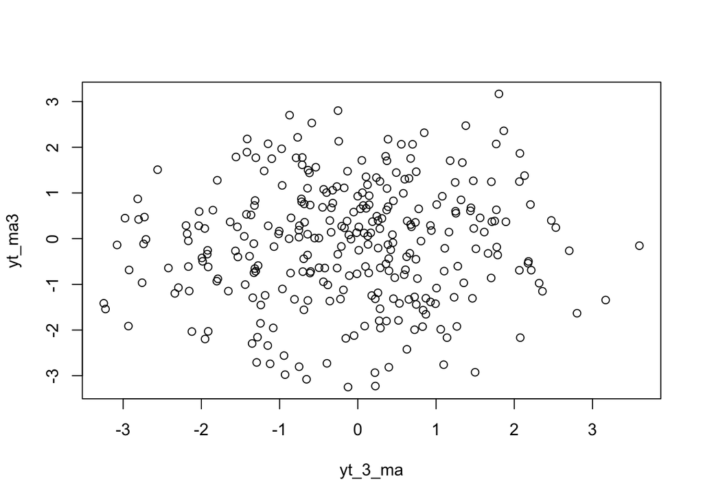

```r
plot(y=yt_ma3,x=yt_3_ma)
```

```r
cor(yt_ma3,yt_3_ma)
```

```
## [1] 0.0612942
```

Berdasarkan scatterplot tersebut, terlihat bahwa cenderung tidak terdapat hubungan antara $Y_t$ dengan $Y_{t-3}$.

## Pembangkitan Proses AR

```r
set.seed(025)
```

Nilai-nilai selanjutnya dapat dicari melalui *loop*. Bentuk loop dapat dilihat dari rumus AR(2) yang hendak dibangkitkan:

$$Y_t = e_t+0.5Y_{t-1}+0.2Y_{t-2}$$

```r
n<-length(wn)
n
```

```
## [1] 300
```

```r
ar <- c(1:n)
for (i in 3:n) {ar[i]<-wn[i]+0.5*ar[i-1]+0.2*ar[i-2]}
ar
```

```
##   [1]  1.000000000  2.000000000  3.447565151  1.930103492  1.108880714
##   [6]  1.121087968 -0.402452685 -1.604024814 -1.702450282 -0.872921208
##  [11] -0.826636303 -0.641051233 -0.269730288 -0.960309884  0.279371324
##  [16]  0.167420066 -0.794626437 -0.442261467  0.270081517 -1.532129793
##  [21]  0.307563100  1.392789201  0.047300405  0.311473992 -0.493731016
##  [26] -1.715974051 -1.278649833 -1.887838299 -1.522682207 -0.575392002
##  [31] -2.819949122 -0.973672789 -0.744576338 -0.733477068  0.296033507
##  [36] -1.550859288 -1.221333900 -1.171883755 -1.173362834 -1.884579778
##  [41] -0.929789071 -0.019007984 -2.966539297 -1.885209903 -1.247565887
##  [46] -1.949136021 -0.913336443 -0.801608731 -0.962288678  0.837256995
##  [51]  0.870238977  0.569119914 -0.881582883  0.975619914  0.383614850
##  [56]  0.741440439  1.727190267  0.116425626  0.137730322 -0.570036212
##  [61]  0.403850063  0.963383343 -0.896049817  1.138824406  0.256677251
##  [66]  1.189305023  2.057428018  0.887110385  0.304549854  0.454605036
##  [71]  0.827868073  1.153892767  1.218779691  0.053980097  0.477300791
```

[output cut: 45 more lines]

Selain menggunakan cara di atas, pembangkitan proses AR dapat dilakukan dengan fungsi `arima.sim()` sebagai berikut.

```r
ar1 <- arima.sim(list(order=c(2,0,0), ar=c(0.5,0.2)), n=300)
ar1
```

```
## Time Series:
## Start = 1
## End = 300
## Frequency = 1
##   [1] -0.617510648  0.570472825  0.230052634 -0.920347068 -1.315437988
##   [6] -2.040241932 -1.793372387 -0.998488236 -0.925795623 -0.290393033
##  [11]  0.814135581 -1.090622970 -1.127892136 -1.866330944 -2.070554358
##  [16] -1.154069507 -0.936602782  0.170281536 -0.598001927  0.524039300
##  [21]  0.094141433  0.436320055 -2.107924768 -0.614558503 -1.465573499
##  [26] -0.702832895 -0.177895607 -1.578136049 -1.195978050  1.134578772
##  [31] -0.702259914 -0.933127911 -1.506528407  0.381759410 -2.013015821
##  [36] -2.365317998 -1.538672055 -1.292590452 -2.241561304 -0.225186293
##  [41] -1.936643499 -2.161657731 -0.051899817 -0.352517842 -0.571298261
##  [46]  1.428329466 -0.515388195 -0.044177864 -0.780096263  0.835866627
##  [51] -0.093089999  0.144921279 -1.066304252 -0.372651154 -1.417480232
```

[output cut: 49 more lines]

## Karakteristik AR(2)

### Plot Time Series

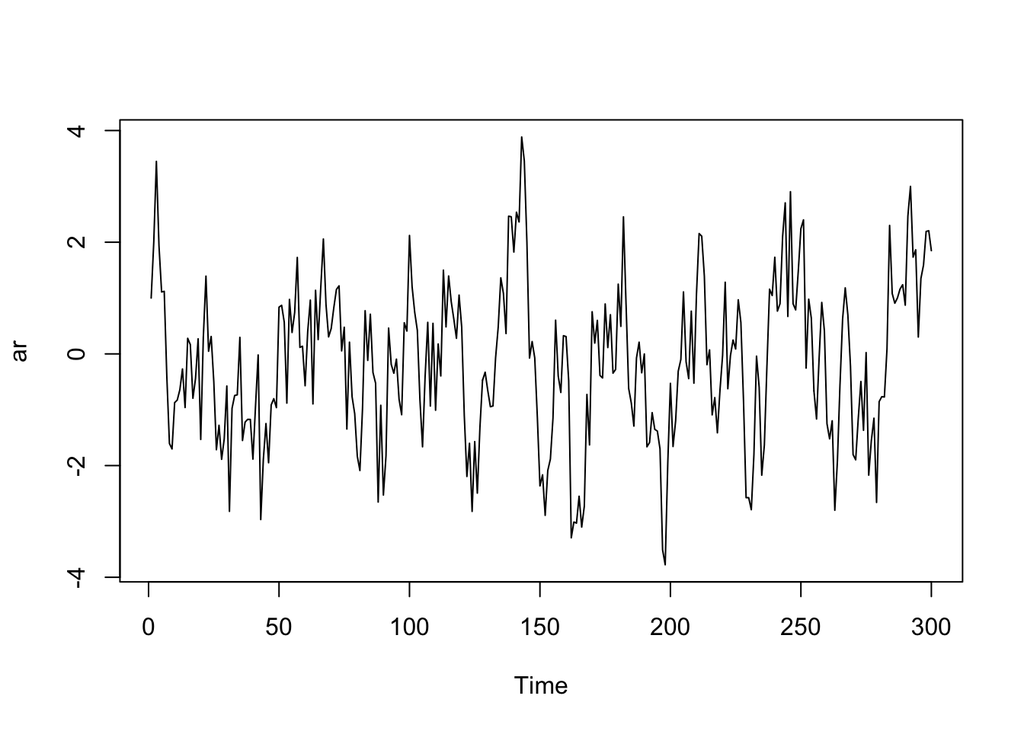

```r
ts.plot(ar)
```

### Plot ACF

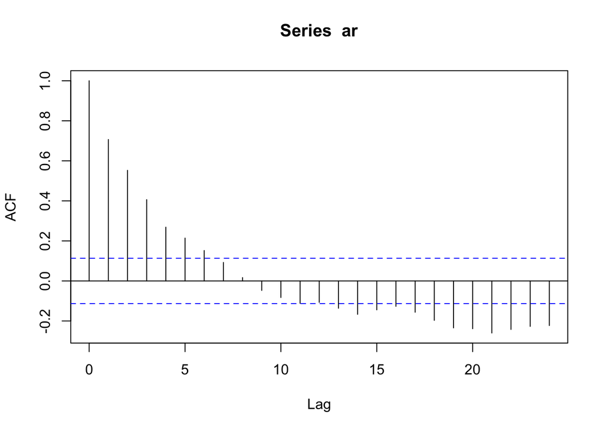

```r
acf(ar)
```

### Plot PACF

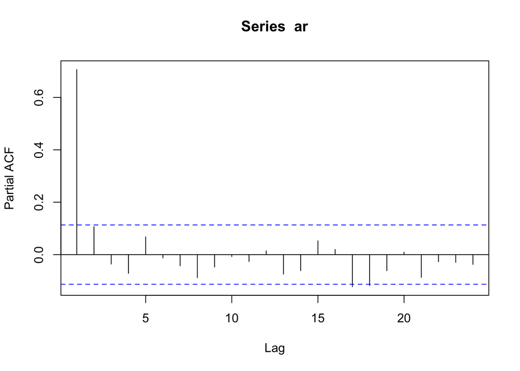

```r
pacf(ar)
```

### Plot EACF

```r
TSA::eacf(ar)
```

```
## AR/MA
##   0 1 2 3 4 5 6 7 8 9 10 11 12 13
## 0 x x x x x x o o o o o  o  x  x
## 1 x o o o o o o o o o o  o  o  o
## 2 x o o o o o o o o o o  o  o  o
## 3 x x o o o o o o o o o  o  o  o
## 4 x x x o o o x o o o o  o  o  o
## 5 x x o o o o x o o o o  o  o  o
## 6 x o x x o o o o o o o  o  o  o
## 7 x o x x o o o o o o o  o  o  o
```

### Scatterplot Antar Lag

#### Korelasi antara $Y_t$ dengan $Y_{t-1}$

```r
#Yt
yt_ar <- ar[-1]
yt_ar
```

```
##   [1]  2.000000000  3.447565151  1.930103492  1.108880714  1.121087968
##   [6] -0.402452685 -1.604024814 -1.702450282 -0.872921208 -0.826636303
##  [11] -0.641051233 -0.269730288 -0.960309884  0.279371324  0.167420066
##  [16] -0.794626437 -0.442261467  0.270081517 -1.532129793  0.307563100
##  [21]  1.392789201  0.047300405  0.311473992 -0.493731016 -1.715974051
##  [26] -1.278649833 -1.887838299 -1.522682207 -0.575392002 -2.819949122
##  [31] -0.973672789 -0.744576338 -0.733477068  0.296033507 -1.550859288
##  [36] -1.221333900 -1.171883755 -1.173362834 -1.884579778 -0.929789071
##  [41] -0.019007984 -2.966539297 -1.885209903 -1.247565887 -1.949136021
##  [46] -0.913336443 -0.801608731 -0.962288678  0.837256995  0.870238977
##  [51]  0.569119914 -0.881582883  0.975619914  0.383614850  0.741440439
##  [56]  1.727190267  0.116425626  0.137730322 -0.570036212  0.403850063
##  [61]  0.963383343 -0.896049817  1.138824406  0.256677251  1.189305023
##  [66]  2.057428018  0.887110385  0.304549854  0.454605036  0.827868073
##  [71]  1.153892767  1.218779691  0.053980097  0.477300791 -1.345793626
```

[output cut: 45 more lines]

```r
#Yt-1
yt_1_ar <- ar[-300]
yt_1_ar
```

```
##   [1]  1.000000000  2.000000000  3.447565151  1.930103492  1.108880714
##   [6]  1.121087968 -0.402452685 -1.604024814 -1.702450282 -0.872921208
##  [11] -0.826636303 -0.641051233 -0.269730288 -0.960309884  0.279371324
##  [16]  0.167420066 -0.794626437 -0.442261467  0.270081517 -1.532129793
##  [21]  0.307563100  1.392789201  0.047300405  0.311473992 -0.493731016
##  [26] -1.715974051 -1.278649833 -1.887838299 -1.522682207 -0.575392002
##  [31] -2.819949122 -0.973672789 -0.744576338 -0.733477068  0.296033507
##  [36] -1.550859288 -1.221333900 -1.171883755 -1.173362834 -1.884579778
##  [41] -0.929789071 -0.019007984 -2.966539297 -1.885209903 -1.247565887
##  [46] -1.949136021 -0.913336443 -0.801608731 -0.962288678  0.837256995
##  [51]  0.870238977  0.569119914 -0.881582883  0.975619914  0.383614850
##  [56]  0.741440439  1.727190267  0.116425626  0.137730322 -0.570036212
##  [61]  0.403850063  0.963383343 -0.896049817  1.138824406  0.256677251
##  [66]  1.189305023  2.057428018  0.887110385  0.304549854  0.454605036
##  [71]  0.827868073  1.153892767  1.218779691  0.053980097  0.477300791
```

[output cut: 45 more lines]

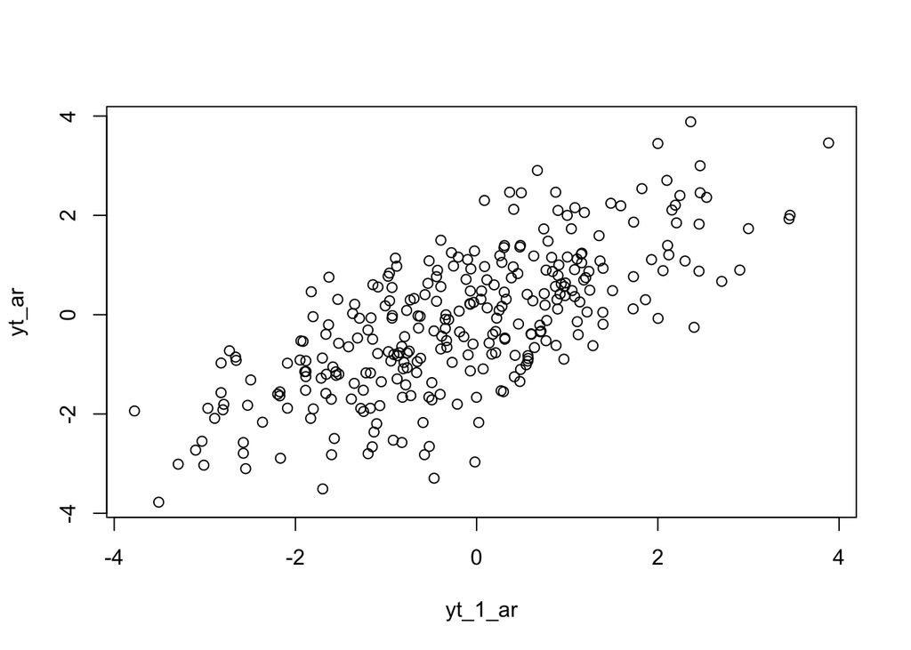

```r
plot(y=yt_ar,x=yt_1_ar)
```

Berdasarkan scatterplot tersebut, terlihat bahwa terdapat hubungan positif antara $Y_t$ dengan $Y_{t-1}$. Hal ini sesuai dengan teori yang ada

```r
cor(yt_ar,yt_1_ar)
```

```
## [1] 0.7097464
```

#### Korelasi antara $Y_t$ dengan $Y_{t-2}$

```r
#Yt
yt_ar2 <- ar[-c(1,2)]
yt_ar2
```

```
##   [1]  3.447565151  1.930103492  1.108880714  1.121087968 -0.402452685
##   [6] -1.604024814 -1.702450282 -0.872921208 -0.826636303 -0.641051233
##  [11] -0.269730288 -0.960309884  0.279371324  0.167420066 -0.794626437
##  [16] -0.442261467  0.270081517 -1.532129793  0.307563100  1.392789201
##  [21]  0.047300405  0.311473992 -0.493731016 -1.715974051 -1.278649833
##  [26] -1.887838299 -1.522682207 -0.575392002 -2.819949122 -0.973672789
##  [31] -0.744576338 -0.733477068  0.296033507 -1.550859288 -1.221333900
##  [36] -1.171883755 -1.173362834 -1.884579778 -0.929789071 -0.019007984
##  [41] -2.966539297 -1.885209903 -1.247565887 -1.949136021 -0.913336443
##  [46] -0.801608731 -0.962288678  0.837256995  0.870238977  0.569119914
##  [51] -0.881582883  0.975619914  0.383614850  0.741440439  1.727190267
##  [56]  0.116425626  0.137730322 -0.570036212  0.403850063  0.963383343
##  [61] -0.896049817  1.138824406  0.256677251  1.189305023  2.057428018
##  [66]  0.887110385  0.304549854  0.454605036  0.827868073  1.153892767
##  [71]  1.218779691  0.053980097  0.477300791 -1.345793626  0.210099515
```

[output cut: 45 more lines]

```r
#Yt-2
yt_2_ar <- ar[-c(299,300)]
yt_2_ar
```

```
##   [1]  1.000000000  2.000000000  3.447565151  1.930103492  1.108880714
##   [6]  1.121087968 -0.402452685 -1.604024814 -1.702450282 -0.872921208
##  [11] -0.826636303 -0.641051233 -0.269730288 -0.960309884  0.279371324
##  [16]  0.167420066 -0.794626437 -0.442261467  0.270081517 -1.532129793
##  [21]  0.307563100  1.392789201  0.047300405  0.311473992 -0.493731016
##  [26] -1.715974051 -1.278649833 -1.887838299 -1.522682207 -0.575392002
##  [31] -2.819949122 -0.973672789 -0.744576338 -0.733477068  0.296033507
##  [36] -1.550859288 -1.221333900 -1.171883755 -1.173362834 -1.884579778
##  [41] -0.929789071 -0.019007984 -2.966539297 -1.885209903 -1.247565887
##  [46] -1.949136021 -0.913336443 -0.801608731 -0.962288678  0.837256995
##  [51]  0.870238977  0.569119914 -0.881582883  0.975619914  0.383614850
##  [56]  0.741440439  1.727190267  0.116425626  0.137730322 -0.570036212
##  [61]  0.403850063  0.963383343 -0.896049817  1.138824406  0.256677251
##  [66]  1.189305023  2.057428018  0.887110385  0.304549854  0.454605036
##  [71]  0.827868073  1.153892767  1.218779691  0.053980097  0.477300791
```

[output cut: 45 more lines]

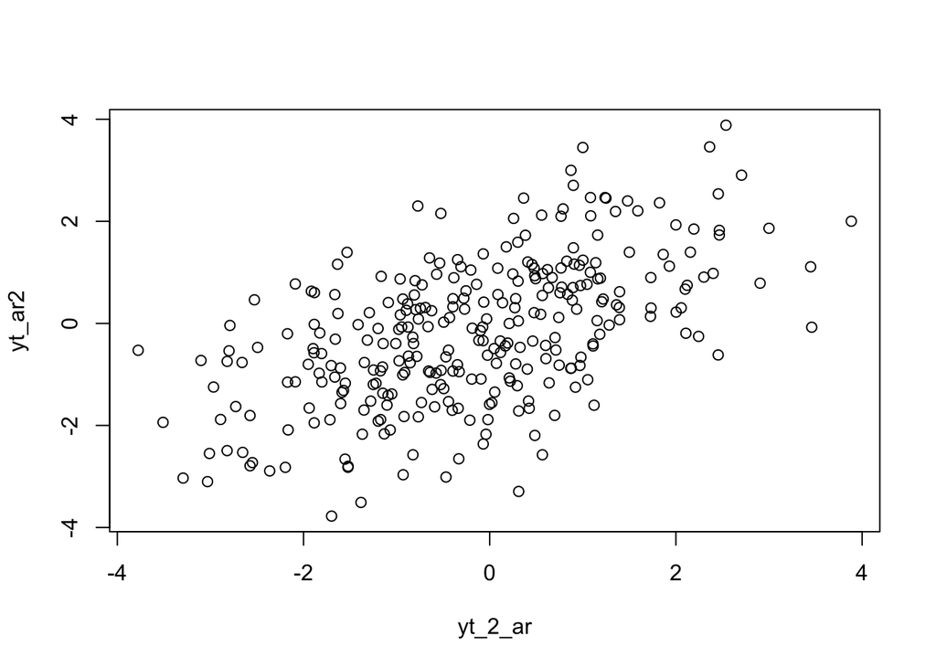

```r
plot(y=yt_ar2,x=yt_2_ar)
```

Berdasarkan scatterplot tersebut, terlihat bahwa terdapat hubungan positif antara $Y_t$ dengan $Y_{t-2}$. Hal ini sesuai dengan teori yang ada

```r
cor(yt_ar2,yt_2_ar)
```

```
## [1] 0.5598759
```

#### Korelasi antara $Y_t$ dengan $Y_{t-3}$

```r
#Yt
yt_ar3 <- ar[-c(1,2,3)]
yt_ar3
```

```
##   [1]  1.930103492  1.108880714  1.121087968 -0.402452685 -1.604024814
##   [6] -1.702450282 -0.872921208 -0.826636303 -0.641051233 -0.269730288
##  [11] -0.960309884  0.279371324  0.167420066 -0.794626437 -0.442261467
##  [16]  0.270081517 -1.532129793  0.307563100  1.392789201  0.047300405
##  [21]  0.311473992 -0.493731016 -1.715974051 -1.278649833 -1.887838299
##  [26] -1.522682207 -0.575392002 -2.819949122 -0.973672789 -0.744576338
##  [31] -0.733477068  0.296033507 -1.550859288 -1.221333900 -1.171883755
##  [36] -1.173362834 -1.884579778 -0.929789071 -0.019007984 -2.966539297
##  [41] -1.885209903 -1.247565887 -1.949136021 -0.913336443 -0.801608731
##  [46] -0.962288678  0.837256995  0.870238977  0.569119914 -0.881582883
##  [51]  0.975619914  0.383614850  0.741440439  1.727190267  0.116425626
##  [56]  0.137730322 -0.570036212  0.403850063  0.963383343 -0.896049817
##  [61]  1.138824406  0.256677251  1.189305023  2.057428018  0.887110385
##  [66]  0.304549854  0.454605036  0.827868073  1.153892767  1.218779691
##  [71]  0.053980097  0.477300791 -1.345793626  0.210099515 -0.766738064
```

[output cut: 45 more lines]

```r
#Yt-2
yt_3_ar <- ar[-c(298,299,300)]
yt_3_ar
```

```
##   [1]  1.000000000  2.000000000  3.447565151  1.930103492  1.108880714
##   [6]  1.121087968 -0.402452685 -1.604024814 -1.702450282 -0.872921208
##  [11] -0.826636303 -0.641051233 -0.269730288 -0.960309884  0.279371324
##  [16]  0.167420066 -0.794626437 -0.442261467  0.270081517 -1.532129793
##  [21]  0.307563100  1.392789201  0.047300405  0.311473992 -0.493731016
##  [26] -1.715974051 -1.278649833 -1.887838299 -1.522682207 -0.575392002
##  [31] -2.819949122 -0.973672789 -0.744576338 -0.733477068  0.296033507
##  [36] -1.550859288 -1.221333900 -1.171883755 -1.173362834 -1.884579778
##  [41] -0.929789071 -0.019007984 -2.966539297 -1.885209903 -1.247565887
##  [46] -1.949136021 -0.913336443 -0.801608731 -0.962288678  0.837256995
##  [51]  0.870238977  0.569119914 -0.881582883  0.975619914  0.383614850
##  [56]  0.741440439  1.727190267  0.116425626  0.137730322 -0.570036212
##  [61]  0.403850063  0.963383343 -0.896049817  1.138824406  0.256677251
##  [66]  1.189305023  2.057428018  0.887110385  0.304549854  0.454605036
##  [71]  0.827868073  1.153892767  1.218779691  0.053980097  0.477300791
```

[output cut: 45 more lines]

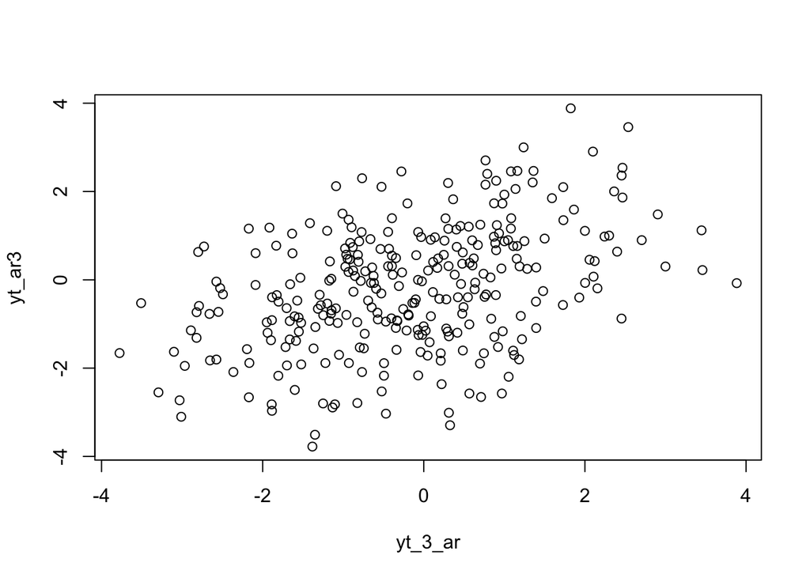

```r
plot(y=yt_ar3,x=yt_3_ar)
```

```r
cor(yt_ar3,yt_3_ar)
```

```
## [1] 0.4180417
```

## Fungsi pembangkitan ARMA

Jika koefisien dan *white noise*/nilai deret waktu sebelumnya dapat diekstrak dalam bentuk vektor, dapat dilakukan perkalian matriks untuk mencari nilai bagian AR dan MA:

```r
set.seed(025)
coefs <- c(0.4, 0.6, 0.5,0.2)
e <- c(1, 2, 3, 4)

coefs %*% e
```

```
##      [,1]
## [1,]  3.9
```

```r
coefs * e
```

```
## [1] 0.4 1.2 1.5 0.8
```

```r
sum(coefs * e)
```

```
## [1] 3.9
```

Dari prinsip ini, dapat dibuat fungsi umum untuk membangkitkan data ARMA. Input dari fungsi adalah jumlah data yang hendak dibangkitkan, koefisien MA, dan koefisien AR

```r
arma.sim <- function(n, macoef, arcoef){
  manum <- length(macoef)
  arnum <- length(arcoef)
  stopifnot(manum < n & arnum < n)

  wn <- rnorm(n, sd = 0.5)
  init <- max(manum, arnum)

  arma <- wn[1:init]
  for(i in {init+1}:n){
   mastart <- i - manum
   maend <- i-1
   arstart <- i - arnum
   arend <- i-1
   arma[i] <- sum(arcoef * arma[arstart:arend]) + sum(macoef * wn[mastart:maend])  + wn[i]
   }
  return(arma)
}
```

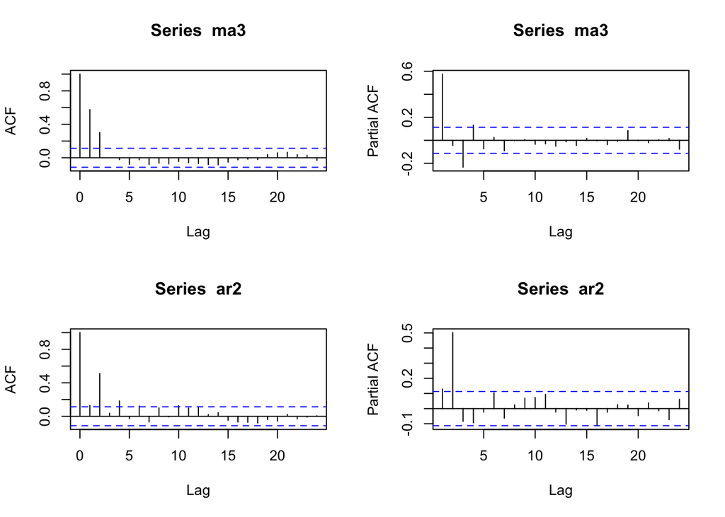

```r
# beberapa contoh pembangkitan melalui fungsi

ma3 <- arma.sim(300, c(0.4, 0.6), 0)
ar2 <- arma.sim(300, 0, c(0.5, 0.2))

par(mfrow = c(2, 2))
acf(ma3)
pacf(ma3)
acf(ar2)
pacf(ar2)
```

```r
#contoh untuk ARMA
arma22 <- arma.sim(300, c(0.4, 0.6), c(0.5, 0.2))

arma22 |> arima(c(2,0,2))
```

```
##
## Call:
## arima(x = arma22, order = c(2, 0, 2))
##
## Coefficients:
##          ar1     ar2     ma1     ma2  intercept
##       0.1641  0.5302  0.6153  0.3181     0.1249
## s.e.  0.1072  0.1021  0.1110  0.0664     0.1778
##
## sigma^2 estimated as 0.2444:  log likelihood = -215.21,  aic = 442.42
```

```r
set.seed(025)
n = length(wn)
phi1 = 0.5
phi2 = 0.2
theta1 = 0.4
theta2 = 0.6

y.arma=c(1:n)
for (i in 5:n){y.arma[i] = phi1*y.arma[i-1] + phi2*y.arma[i-2] + theta1*wn[i-1] + theta2*wn[i-2] +wn[i]}
```

Pembangkitan ARMA(p,q) juga dapat dilakukan dengan fungsi `arima.sim` sebagai berikut.

```r
arma22 <- arima.sim(list(order=c(2,0,2), ar = c(0.5,0.2), ma = c(0.4,0.6)), n=300)
arma22
```

```
## Time Series:
## Start = 1
## End = 300
## Frequency = 1
##   [1]  0.088562156 -0.485412026 -1.545064732 -3.118259057 -3.398452696
##   [6] -2.939769460 -2.401052054 -1.259680498  0.142595316 -0.939132651
##  [11] -1.075605158 -2.971819790 -3.493790159 -3.102065530 -2.640544684
##  [16] -0.896787166 -1.091840221  0.387015654 -0.055037750  0.788404976
##  [21] -1.876908252 -1.195933607 -2.976149649 -1.657795787 -1.338371637
##  [26] -2.070993093 -1.933969121 -0.290693534 -0.966014821 -0.533284297
##  [31] -2.301135279 -0.780728516 -2.764228961 -2.941468574 -3.692608665
##  [36] -3.327250010 -3.681800670 -1.897365049 -3.371654771 -3.071426885
##  [41] -2.078548993 -1.670272396 -0.743445279  0.988299463 -0.286835360
##  [46]  0.606664542 -1.107000323  0.497321405 -0.226801104  0.609205256
##  [51] -1.064189738 -0.712220087 -2.206323244 -0.029728044 -1.061713285
```

[output cut: 49 more lines]

## Karakteristik ARMA(2,2)

### Plot Time Series

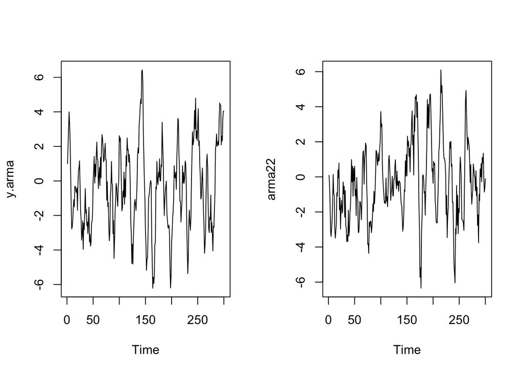

```r
par(mfrow = c(1, 2))
ts.plot(y.arma)
ts.plot(arma22)
```

```r
par(mfrow = c(1, 1))
```

Berdasarkan plot time series tersebut, terlihat bahwa model ARMA(2,2) cenderung stasioner dalam rataan

### Plot ACF

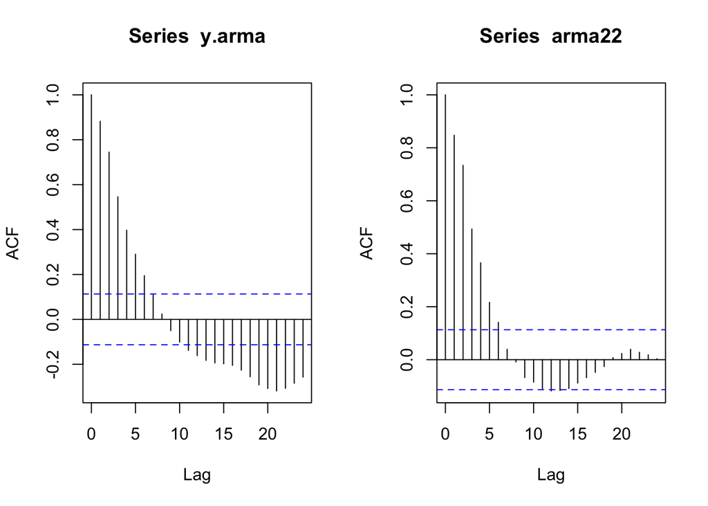

```r
par(mfrow = c(1, 2))
acf(y.arma)
acf(arma22)
```

```r
par(mfrow = c(1, 1))
```

### Plot PACF

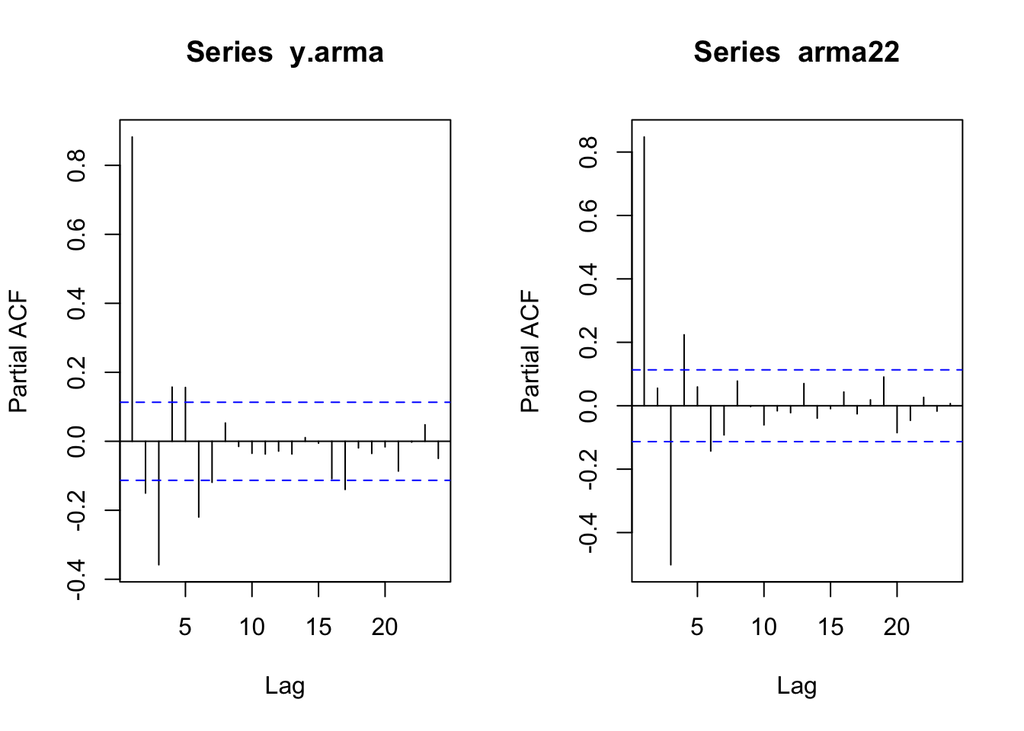

```r
par(mfrow = c(1, 2))
pacf(y.arma)
pacf(arma22)
```

```r
par(mfrow = c(1, 1))
```

### Plot EACF

```r
TSA::eacf(y.arma)
```

```
## AR/MA
##   0 1 2 3 4 5 6 7 8 9 10 11 12 13
## 0 x x x x x x o o o o x  x  x  x
## 1 x x o o o o o o o o o  o  o  o
## 2 x x x o o o o o o o o  o  o  o
## 3 x x o o o o o o o o o  o  o  o
## 4 x x x x x o o o o o o  o  o  o
## 5 x x x x x x o o o o o  o  o  o
## 6 x x x x x o x o o o o  o  o  o
## 7 x o x x x o o x o o o  o  o  o
```

```r
TSA::eacf(arma22)
```

```
## AR/MA
##   0 1 2 3 4 5 6 7 8 9 10 11 12 13
## 0 x x x x x x o o o o o  x  o  o
## 1 o x x x o x o o x o o  o  o  o
## 2 o x x x o x o o x o o  o  o  o
## 3 x x x x o o o o o o o  o  o  o
## 4 x x o x o o o o o o o  o  o  o
## 5 x x o x o o o o o o o  o  o  o
## 6 x x o x o o o o o o o  o  o  o
## 7 x x x x o o o o o x o  o  o  o
```

### Scatterplot Antar Lag

#### Korelasi antara $Y_t$ dengan $Y_{t-1}$

```r
#Yt
yt_arma <- arma22[-1]
yt_arma
```

```
##   [1] -0.485412026 -1.545064732 -3.118259057 -3.398452696 -2.939769460
##   [6] -2.401052054 -1.259680498  0.142595316 -0.939132651 -1.075605158
##  [11] -2.971819790 -3.493790159 -3.102065530 -2.640544684 -0.896787166
##  [16] -1.091840221  0.387015654 -0.055037750  0.788404976 -1.876908252
##  [21] -1.195933607 -2.976149649 -1.657795787 -1.338371637 -2.070993093
##  [26] -1.933969121 -0.290693534 -0.966014821 -0.533284297 -2.301135279
##  [31] -0.780728516 -2.764228961 -2.941468574 -3.692608665 -3.327250010
##  [36] -3.681800670 -1.897365049 -3.371654771 -3.071426885 -2.078548993
##  [41] -1.670272396 -0.743445279  0.988299463 -0.286835360  0.606664542
##  [46] -1.107000323  0.497321405 -0.226801104  0.609205256 -1.064189738
##  [51] -0.712220087 -2.206323244 -0.029728044 -1.061713285 -1.330773797
##  [56] -3.174248042 -3.158083063 -2.529788044 -1.397179364 -1.439936366
##  [61] -1.769809482 -2.444842422 -1.115354556  0.700817208  1.428951621
##  [66]  1.484791082 -0.415954005  1.015560649  1.292265115  1.929279326
##  [71]  1.772206140 -0.440786246 -1.375436590 -3.841199601 -3.807361200
```

[output cut: 45 more lines]

```r
#Yt-1
yt_1_arma <- arma22[-300]
yt_1_arma
```

```
##   [1]  0.088562156 -0.485412026 -1.545064732 -3.118259057 -3.398452696
##   [6] -2.939769460 -2.401052054 -1.259680498  0.142595316 -0.939132651
##  [11] -1.075605158 -2.971819790 -3.493790159 -3.102065530 -2.640544684
##  [16] -0.896787166 -1.091840221  0.387015654 -0.055037750  0.788404976
##  [21] -1.876908252 -1.195933607 -2.976149649 -1.657795787 -1.338371637
##  [26] -2.070993093 -1.933969121 -0.290693534 -0.966014821 -0.533284297
##  [31] -2.301135279 -0.780728516 -2.764228961 -2.941468574 -3.692608665
##  [36] -3.327250010 -3.681800670 -1.897365049 -3.371654771 -3.071426885
##  [41] -2.078548993 -1.670272396 -0.743445279  0.988299463 -0.286835360
##  [46]  0.606664542 -1.107000323  0.497321405 -0.226801104  0.609205256
##  [51] -1.064189738 -0.712220087 -2.206323244 -0.029728044 -1.061713285
##  [56] -1.330773797 -3.174248042 -3.158083063 -2.529788044 -1.397179364
##  [61] -1.439936366 -1.769809482 -2.444842422 -1.115354556  0.700817208
##  [66]  1.428951621  1.484791082 -0.415954005  1.015560649  1.292265115
##  [71]  1.929279326  1.772206140 -0.440786246 -1.375436590 -3.841199601
```

[output cut: 45 more lines]

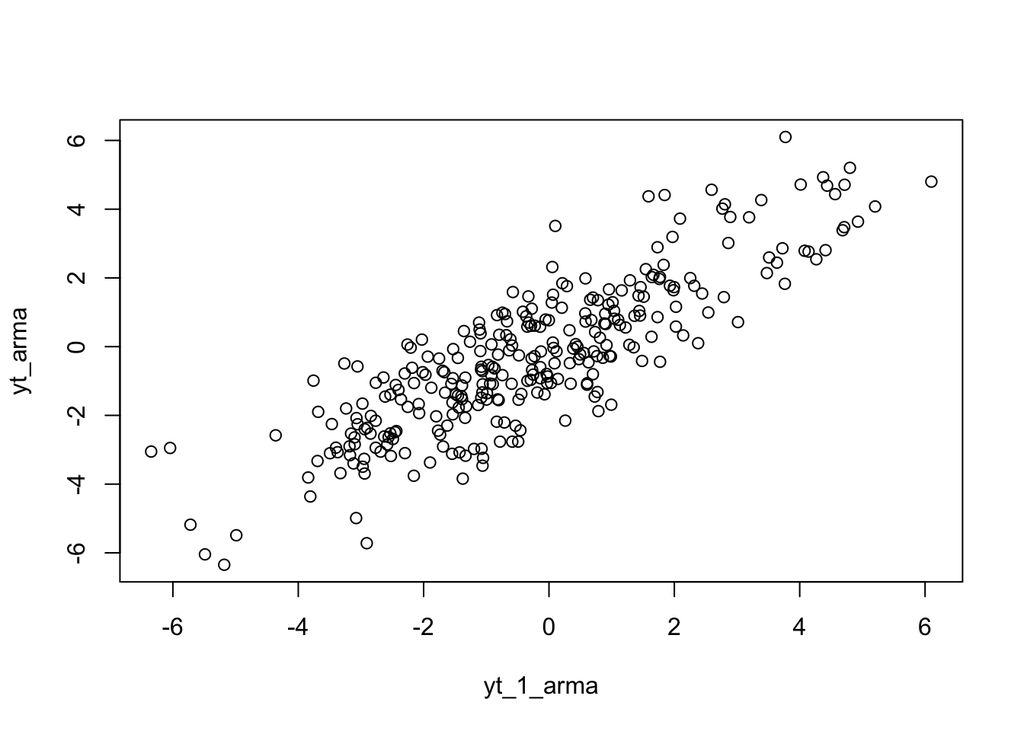

```r
plot(y=yt_arma,x=yt_1_arma)
```

Berdasarkan scatterplot tersebut, terlihat bahwa terdapat hubungan positif antara $Y_t$ dengan $Y_{t-1}$. Hal ini sesuai dengan teori yang ada

```r
cor(yt_arma,yt_1_arma)
```

```
## [1] 0.8475166
```

#### Korelasi antara $Y_t$ dengan $Y_{t-2}$

```r
#Yt
yt_arma <- arma22[-c(1,2)]
yt_arma
```

```
##   [1] -1.545064732 -3.118259057 -3.398452696 -2.939769460 -2.401052054
##   [6] -1.259680498  0.142595316 -0.939132651 -1.075605158 -2.971819790
##  [11] -3.493790159 -3.102065530 -2.640544684 -0.896787166 -1.091840221
##  [16]  0.387015654 -0.055037750  0.788404976 -1.876908252 -1.195933607
##  [21] -2.976149649 -1.657795787 -1.338371637 -2.070993093 -1.933969121
##  [26] -0.290693534 -0.966014821 -0.533284297 -2.301135279 -0.780728516
##  [31] -2.764228961 -2.941468574 -3.692608665 -3.327250010 -3.681800670
##  [36] -1.897365049 -3.371654771 -3.071426885 -2.078548993 -1.670272396
##  [41] -0.743445279  0.988299463 -0.286835360  0.606664542 -1.107000323
##  [46]  0.497321405 -0.226801104  0.609205256 -1.064189738 -0.712220087
##  [51] -2.206323244 -0.029728044 -1.061713285 -1.330773797 -3.174248042
##  [56] -3.158083063 -2.529788044 -1.397179364 -1.439936366 -1.769809482
##  [61] -2.444842422 -1.115354556  0.700817208  1.428951621  1.484791082
##  [66] -0.415954005  1.015560649  1.292265115  1.929279326  1.772206140
##  [71] -0.440786246 -1.375436590 -3.841199601 -3.807361200 -4.360596056
```

[output cut: 45 more lines]

```r
#Yt-2
yt_2_arma <- arma22[-c(299,300)]
yt_2_arma
```

```
##   [1]  0.088562156 -0.485412026 -1.545064732 -3.118259057 -3.398452696
##   [6] -2.939769460 -2.401052054 -1.259680498  0.142595316 -0.939132651
##  [11] -1.075605158 -2.971819790 -3.493790159 -3.102065530 -2.640544684
##  [16] -0.896787166 -1.091840221  0.387015654 -0.055037750  0.788404976
##  [21] -1.876908252 -1.195933607 -2.976149649 -1.657795787 -1.338371637
##  [26] -2.070993093 -1.933969121 -0.290693534 -0.966014821 -0.533284297
##  [31] -2.301135279 -0.780728516 -2.764228961 -2.941468574 -3.692608665
##  [36] -3.327250010 -3.681800670 -1.897365049 -3.371654771 -3.071426885
##  [41] -2.078548993 -1.670272396 -0.743445279  0.988299463 -0.286835360
##  [46]  0.606664542 -1.107000323  0.497321405 -0.226801104  0.609205256
##  [51] -1.064189738 -0.712220087 -2.206323244 -0.029728044 -1.061713285
##  [56] -1.330773797 -3.174248042 -3.158083063 -2.529788044 -1.397179364
##  [61] -1.439936366 -1.769809482 -2.444842422 -1.115354556  0.700817208
##  [66]  1.428951621  1.484791082 -0.415954005  1.015560649  1.292265115
##  [71]  1.929279326  1.772206140 -0.440786246 -1.375436590 -3.841199601
```

[output cut: 45 more lines]

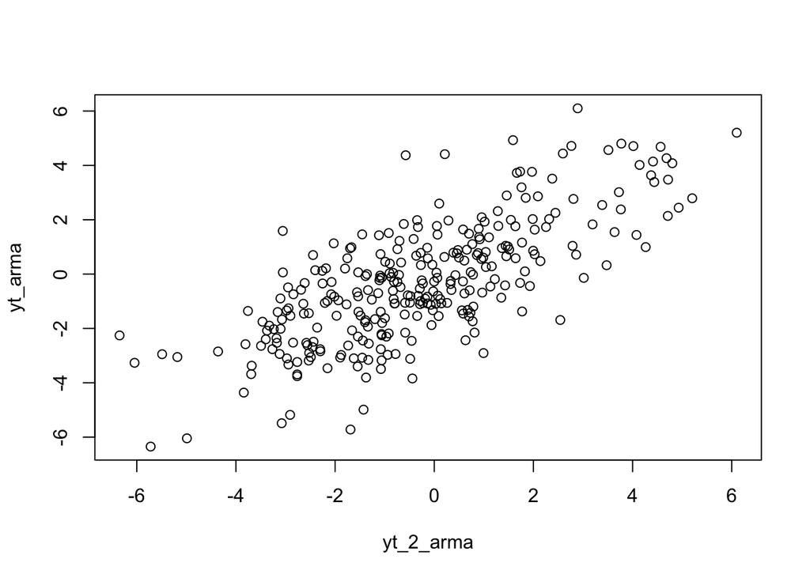

```r
plot(y=yt_arma,x=yt_2_arma)
```

Berdasarkan scatterplot tersebut, terlihat bahwa terdapat hubungan positif antara $Y_t$ dengan $Y_{t-2}$. Hal ini sesuai dengan teori yang ada

```r
cor(yt_arma,yt_2_arma)
```

```
## [1] 0.7338365
```

#### Korelasi antara $Y_t$ dengan $Y_{t-3}$

```r
#Yt
yt_arma <- arma22[-c(1,2,3)]
yt_arma
```

```
##   [1] -3.118259057 -3.398452696 -2.939769460 -2.401052054 -1.259680498
##   [6]  0.142595316 -0.939132651 -1.075605158 -2.971819790 -3.493790159
##  [11] -3.102065530 -2.640544684 -0.896787166 -1.091840221  0.387015654
##  [16] -0.055037750  0.788404976 -1.876908252 -1.195933607 -2.976149649
##  [21] -1.657795787 -1.338371637 -2.070993093 -1.933969121 -0.290693534
##  [26] -0.966014821 -0.533284297 -2.301135279 -0.780728516 -2.764228961
##  [31] -2.941468574 -3.692608665 -3.327250010 -3.681800670 -1.897365049
##  [36] -3.371654771 -3.071426885 -2.078548993 -1.670272396 -0.743445279
##  [41]  0.988299463 -0.286835360  0.606664542 -1.107000323  0.497321405
##  [46] -0.226801104  0.609205256 -1.064189738 -0.712220087 -2.206323244
##  [51] -0.029728044 -1.061713285 -1.330773797 -3.174248042 -3.158083063
##  [56] -2.529788044 -1.397179364 -1.439936366 -1.769809482 -2.444842422
##  [61] -1.115354556  0.700817208  1.428951621  1.484791082 -0.415954005
##  [66]  1.015560649  1.292265115  1.929279326  1.772206140 -0.440786246
##  [71] -1.375436590 -3.841199601 -3.807361200 -4.360596056 -2.580020575
```

[output cut: 45 more lines]

```r
#Yt-2
yt_3_arma <- arma22[-c(298,299,300)]
yt_3_arma
```

```
##   [1]  0.088562156 -0.485412026 -1.545064732 -3.118259057 -3.398452696
##   [6] -2.939769460 -2.401052054 -1.259680498  0.142595316 -0.939132651
##  [11] -1.075605158 -2.971819790 -3.493790159 -3.102065530 -2.640544684
##  [16] -0.896787166 -1.091840221  0.387015654 -0.055037750  0.788404976
##  [21] -1.876908252 -1.195933607 -2.976149649 -1.657795787 -1.338371637
##  [26] -2.070993093 -1.933969121 -0.290693534 -0.966014821 -0.533284297
##  [31] -2.301135279 -0.780728516 -2.764228961 -2.941468574 -3.692608665
##  [36] -3.327250010 -3.681800670 -1.897365049 -3.371654771 -3.071426885
##  [41] -2.078548993 -1.670272396 -0.743445279  0.988299463 -0.286835360
##  [46]  0.606664542 -1.107000323  0.497321405 -0.226801104  0.609205256
##  [51] -1.064189738 -0.712220087 -2.206323244 -0.029728044 -1.061713285
##  [56] -1.330773797 -3.174248042 -3.158083063 -2.529788044 -1.397179364
##  [61] -1.439936366 -1.769809482 -2.444842422 -1.115354556  0.700817208
##  [66]  1.428951621  1.484791082 -0.415954005  1.015560649  1.292265115
##  [71]  1.929279326  1.772206140 -0.440786246 -1.375436590 -3.841199601
```

[output cut: 45 more lines]

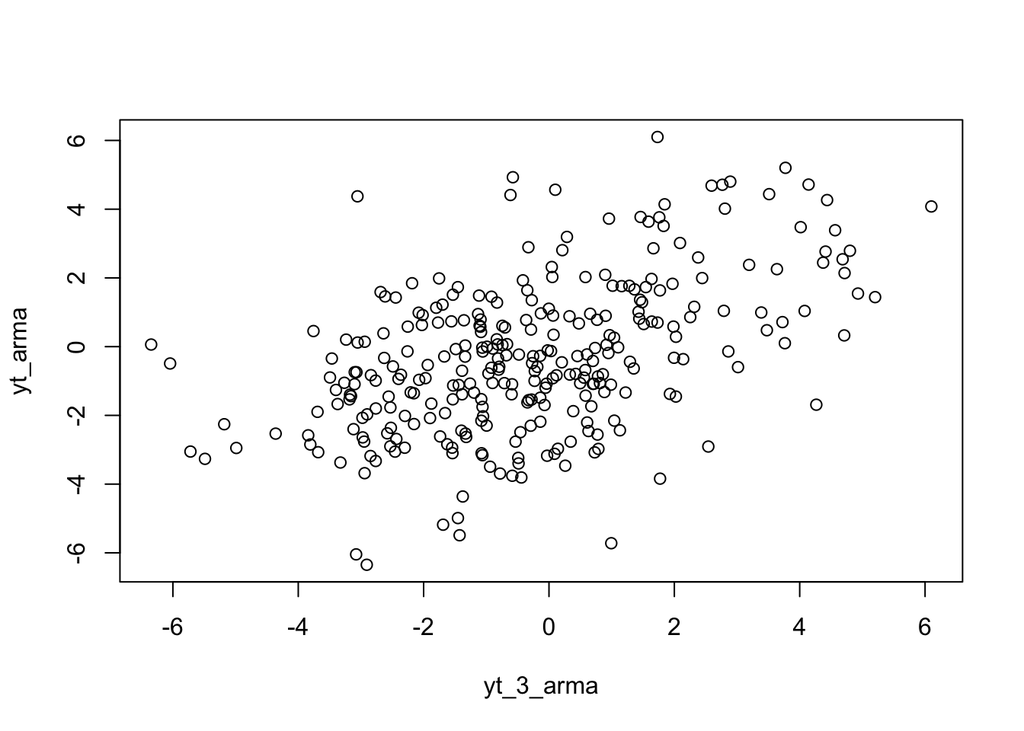

```r
plot(y=yt_arma,x=yt_3_arma)
```

Berdasarkan scatterplot tersebut, terlihat bahwa terdapat hubungan positif antara $Y_t$ dengan $Y_{t-3}$. Hal ini sesuai dengan teori yang ada

```r
cor(yt_arma,yt_3_arma)
```

```
## [1] 0.4937557
```